# R for Data Science

홍우헌

quasar103@naver.com

2018-07-29

> Part 2  
> Wrangle(4)

# 1 Chapter 12 : Factors with forcats

```r
x1 <- c("Dec", "Apr", "Jan", "Mar")
```

정렬을 해도 알파벳 순으로 될 뿐이다. 이 문제를 펙터로 해결하자.

```r
month_levels <- c(
  "Jan", "Feb", "Mar", "Apr", "May", "Jun",
"Jul", "Aug", "Sep", "Oct", "Nov", "Dec"
)
x2 <- c("Dec", "Apr", "Jam", "Mar")
```

```r
y1 <- factor(x1, levels = month_levels)
y1
```

```
## [1] Dec Apr Jan Mar
## Levels: Jan Feb Mar Apr May Jun Jul Aug Sep Oct Nov Dec
```

```r
sort(y1)
```

```
## [1] Jan Mar Apr Dec
## Levels: Jan Feb Mar Apr May Jun Jul Aug Sep Oct Nov Dec
```

집합에 없는 값이 있다면 NA로 변환

```r
y2 <- factor(x2, levels = month_levels)
y2
```

```
## [1] Dec  Apr  <NA> Mar
## Levels: Jan Feb Mar Apr May Jun Jul Aug Sep Oct Nov Dec
```

levels를 생략한다면 알파벳순서로 레벨이 정해진다.

```r
factor(x1)
```

```
## [1] Dec Apr Jan Mar
## Levels: Apr Dec Jan Mar
```

원래의 x1순서 그대로 level을 정하고 싶다면 unique()또는 fact_inorder()사용

```r
f1 <- factor(x1, levels = unique(x1))
f1
```

```
## [1] Dec Apr Jan Mar
## Levels: Dec Apr Jan Mar
```

```r
# fct_inorder : Reorder factors levels by first appearance or frequency
f2 <- x1 %>% factor() %>% fct_inorder()
```

레벨이 직접 접근하고 싶다면

```r
levels(f2)
```

```
## [1] "Dec" "Apr" "Jan" "Mar"
```

## 1.1 General Social Survey

```r
gss_cat
```

```
## # A tibble: 21,483 x 9
##     year marital     age race  rincome   partyid    relig    denom   tvhours
##    <int> <fct>     <int> <fct> <fct>     <fct>      <fct>    <fct>     <int>
##  1  2000 Never ma~    26 White $8000 to~ Ind,near ~ Protest~ Southe~      12
##  2  2000 Divorced     48 White $8000 to~ Not str r~ Protest~ Baptis~      NA
##  3  2000 Widowed      67 White Not appl~ Independe~ Protest~ No den~       2
##  4  2000 Never ma~    39 White Not appl~ Ind,near ~ Orthodo~ Not ap~       4
##  5  2000 Divorced     25 White Not appl~ Not str d~ None     Not ap~       1
##  6  2000 Married      25 White $20000 -~ Strong de~ Protest~ Southe~      NA
##  7  2000 Never ma~    36 White $25000 o~ Not str r~ Christi~ Not ap~       3
##  8  2000 Divorced     44 White $7000 to~ Ind,near ~ Protest~ Luther~      NA
##  9  2000 Married      44 White $25000 o~ Not str d~ Protest~ Other         0
## 10  2000 Married      47 White $25000 o~ Strong re~ Protest~ Southe~       3
## # ... with 21,473 more rows
```

```r
gss_cat %>%
  count(race)
```

```
## # A tibble: 3 x 2
##   race      n
##   <fct> <int>
## 1 Other  1959
## 2 Black  3129
## 3 White 16395
```

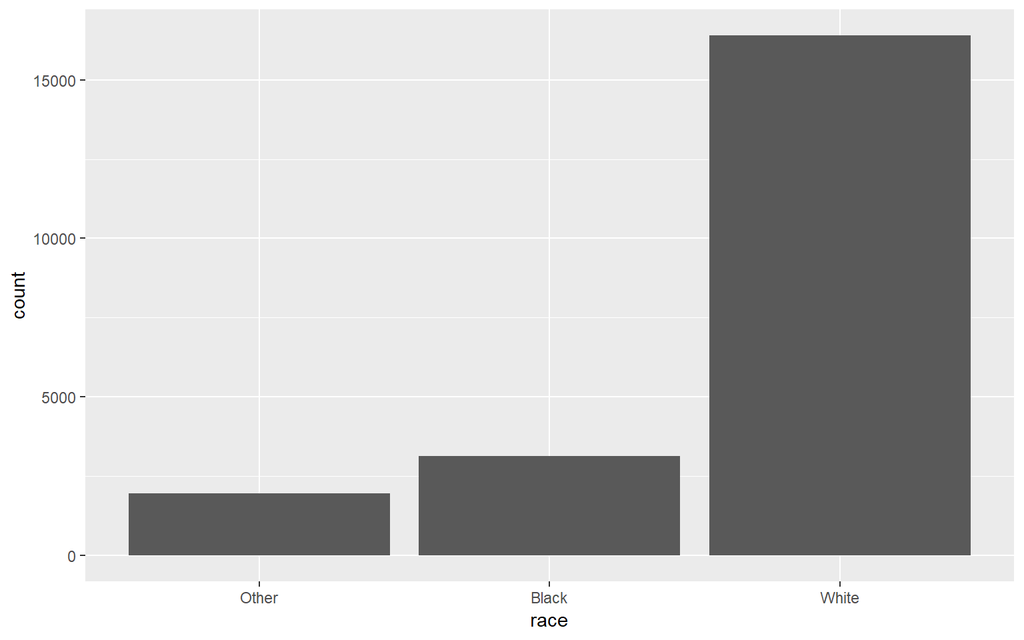

```r
ggplot(gss_cat, aes(race)) +
  geom_bar()
```

ggplot2는 디폴트로 값이 없는 level을 제거하지만 출력시킬 수 있다.

```r
levels(gss_cat$race) # level이 실제로는 하나 더 있다.
```

```
## [1] "Other"          "Black"          "White"          "Not applicable"
```

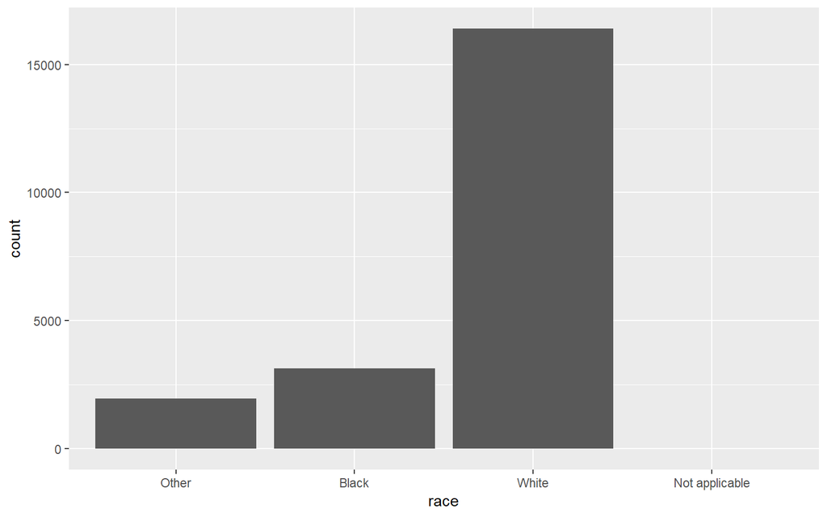

```r
ggplot(gss_cat, aes(race)) +
  geom_bar() +
  scale_x_discrete(drop = FALSE)
```

## 1.2 Exercises

1. Explore the distribution of rincome (reported income). What makes the default bar chart hard to understand? How could you improve the plot?

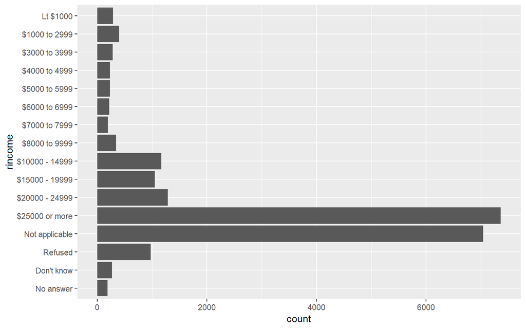

```r
gss_cat %>%
  mutate(rincome =
           fct_relevel(rincome,
                       c("No answer", "Don't know", "Refused", "Not applicable"))) %>%
  ggplot(aes(rincome)) +
  geom_bar() +
  coord_flip()
```

2. Which relig does denom (denomination) apply to? How can you find out with a table? How can you find out with a visualization?

```r
# with(gss_cat, table(relig, denom))
```

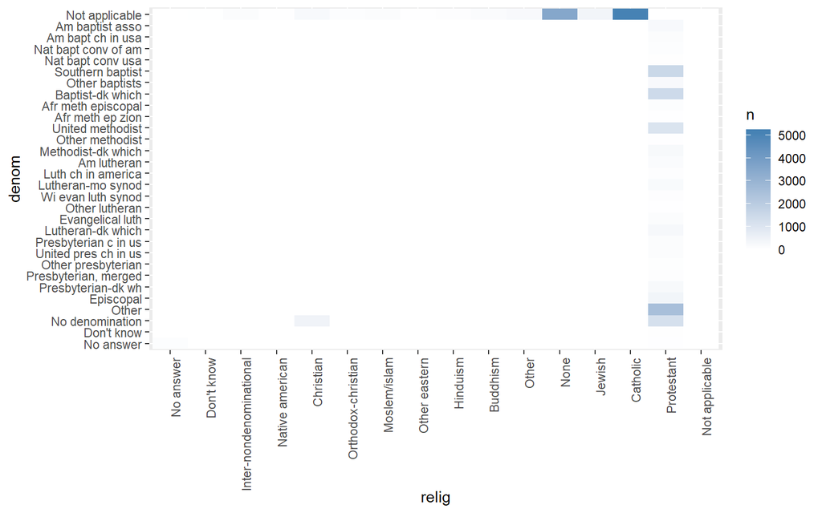

```r
gss_cat %>% group_by(relig, denom) %>%
  summarize(n = n()) %>%
  complete(relig, denom, fill = list(n = 0)) %>% # NA를 0으로
  ggplot() +
  geom_tile(mapping = aes(x = relig, y =  denom, fill = n)) +
  scale_fill_gradient(low = 'white', high = 'steelblue') +
  theme(axis.text.x=element_text(angle=90, hjust=1))
```

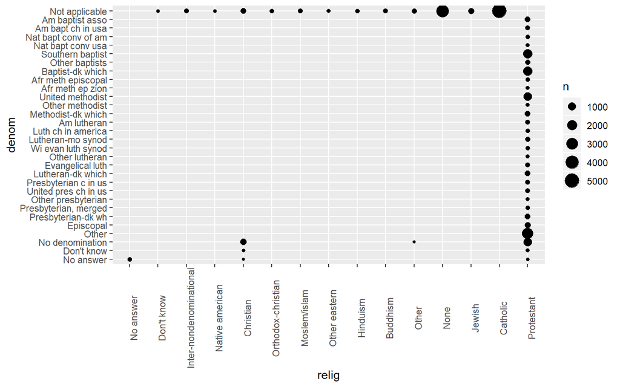

```r
gss_cat %>%
  count(relig, denom) %>%
  ggplot(aes(x = relig, y = denom, size = n)) +
  geom_point() +
  theme(axis.text.x = element_text(angle = 90))
```

## 1.3 Modifying Factor Order

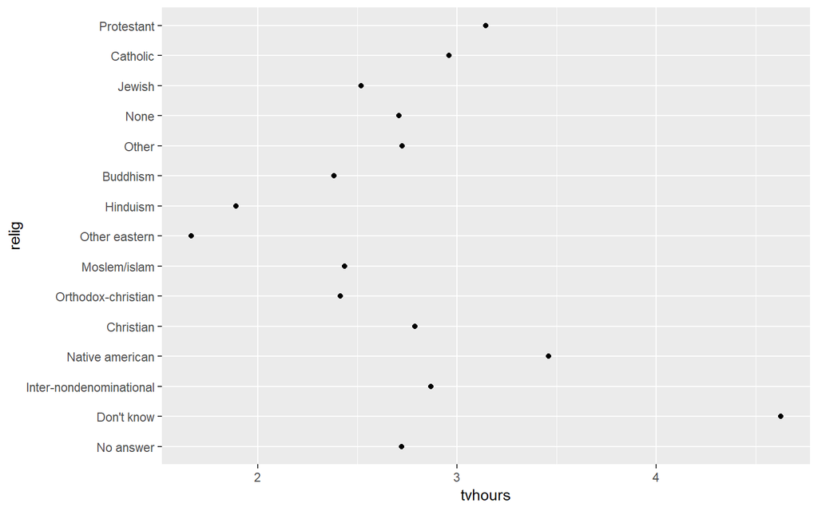

```r
relig <- gss_cat %>%
  group_by(relig) %>%
  summarize(
    age = mean(age, na.rm = TRUE),
    tvhours = mean(tvhours, na.rm = TRUE),
    n = n()
  )
ggplot(relig, aes(tvhours, relig)) + geom_point()
```

전반적인 패턴이 없기 때문에 해석하기 어렵다.

`fct_reorder()`의 세가지 인자

- f, 레벨을 수정하기를 원하는 팩터
- x, 레벨을 수정하기 위해 사용하고자 하는 수치벡터
- 선택적으로, fun, f의 값에 다수의 x값을 이용하고자 하는 함수 디폴트는 중앙값이다.

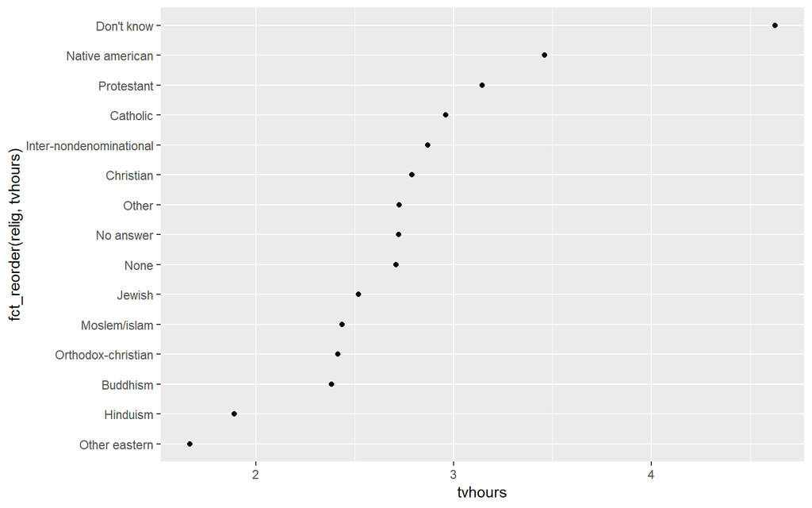

```r
ggplot(relig, aes(tvhours, fct_reorder(relig, tvhours))) +
  geom_point()
```

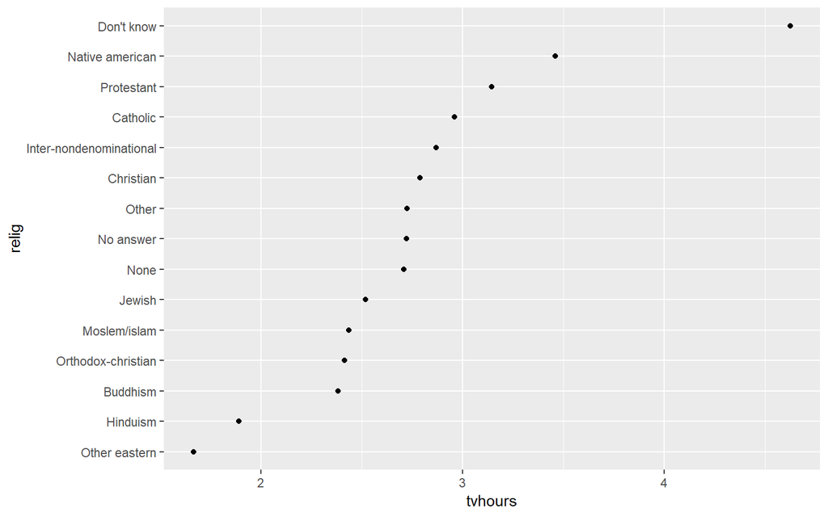

```r
relig %>%
  mutate(relig = fct_reorder(relig, tvhours)) %>%
  ggplot(aes(tvhours, relig)) +
    geom_point()
```

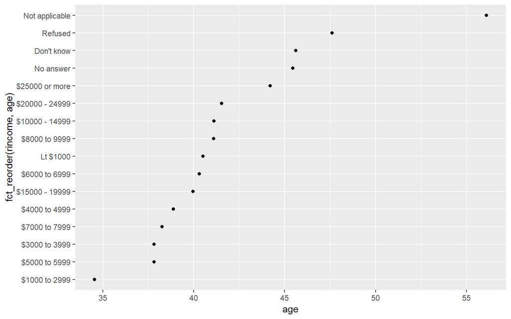

```r
rincome <- gss_cat %>%
  group_by(rincome) %>%
  summarize(
    age = mean(age, na.rm = TRUE),
    tvhours = mean(tvhours, na.rm = TRUE),
    n = n()
  )

ggplot(
  rincome,
  aes(age, fct_reorder(rincome, age))
) + geom_point()
```

Not applicable을 첫번째 라인으로 옮기자.

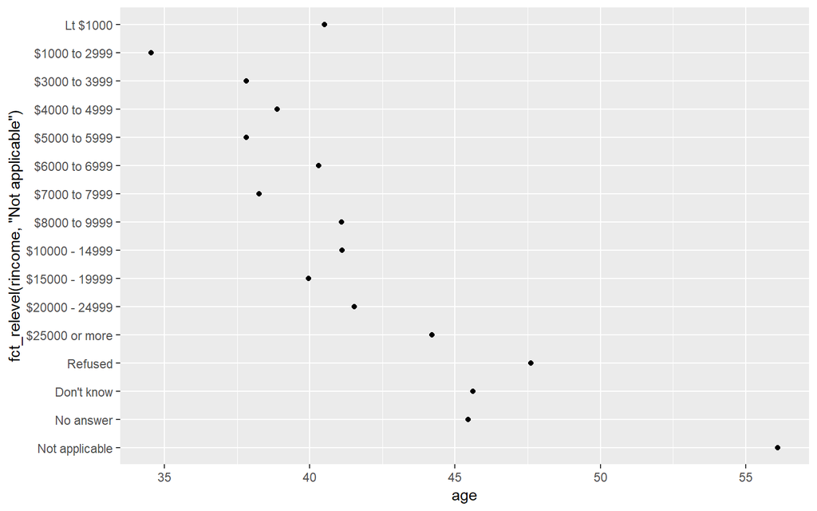

```r
ggplot(
  rincome,
  aes(age, fct_relevel(rincome, "Not applicable"))
) +
  geom_point()
```

왜 해당사항 없음이 가장 평균 나이가 높을까?

플랏에 선을 추가할 때 유용한 `fct_reorder2()`은 가장큰 x값과 관련된 y에 의해 reorder. 이것은 라인 색을 범례와 함께 일렬로 세우기 때문에 플랏을 읽기 쉽다.

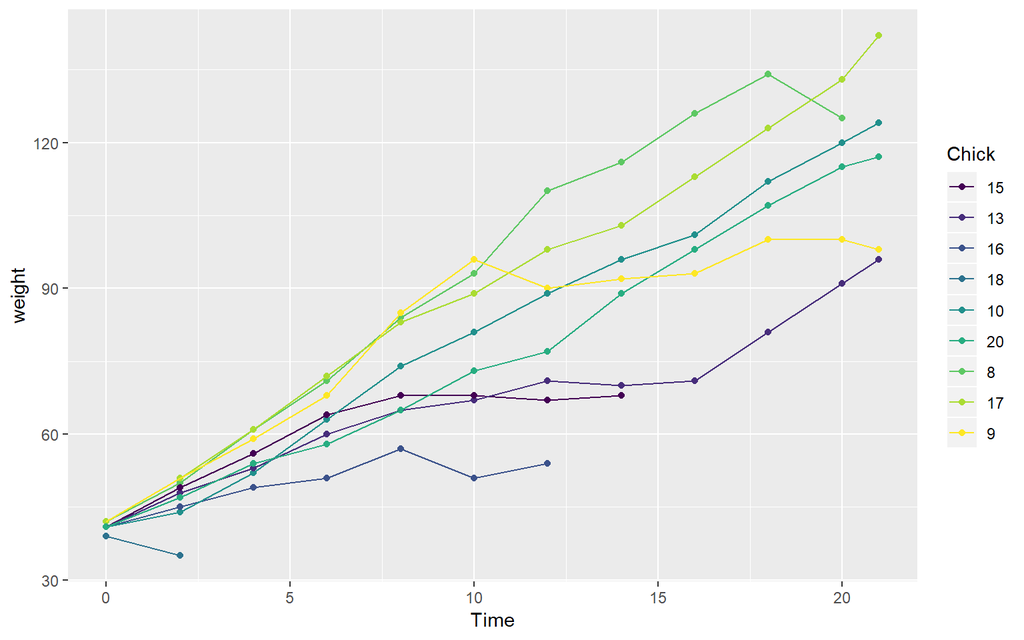

```r
chks <- subset(ChickWeight, as.integer(Chick) < 10)
chks <- transform(chks, Chick = fct_shuffle(Chick))

# 범례 순서와 선 순서가 안맞다
ggplot(chks, aes(Time, weight, colour = Chick)) +
  geom_point() +
  geom_line() +
  labs(colour = "Chick")
```

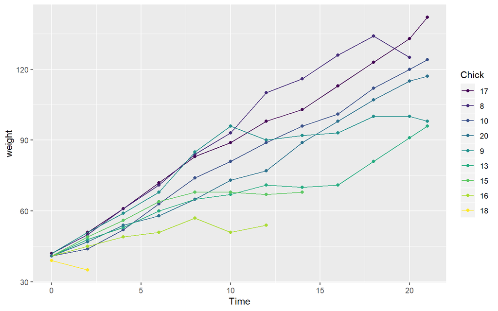

```r
# Note that lines match order in legend
ggplot(chks, aes(Time, weight, colour = fct_reorder2(Chick, Time, weight))) +
  geom_point() +
  geom_line() +
  labs(colour = "Chick")
```

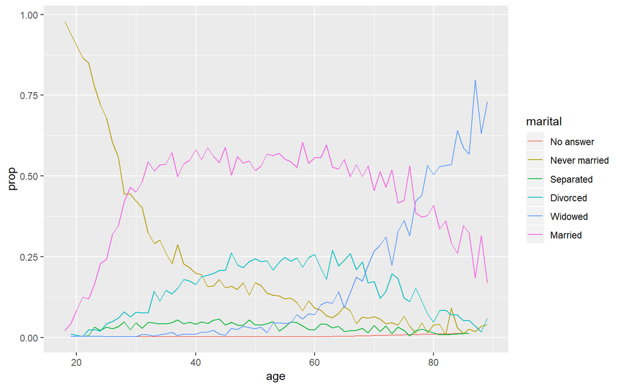

```r
by_age <- gss_cat %>%
  filter(!is.na(age)) %>%
  group_by(age, marital) %>%
  summarise(n = n()) %>% # 여기서 count쓰면 오류
  mutate(prop = n / sum(n))

ggplot(by_age, aes(age, prop, color = marital)) +
  geom_line(na.rm = TRUE)
```

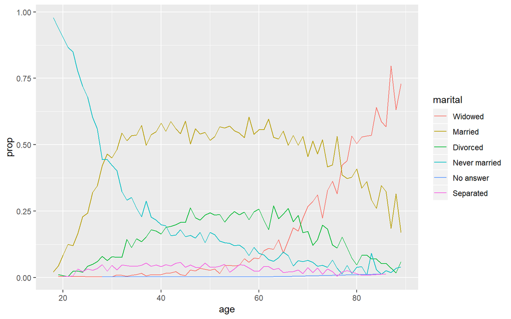

```r
ggplot(by_age, aes(age, prop, color = fct_reorder2(marital, age, prop))) +
  geom_line() +
  labs(color = "marital")
```

`fct_infreq()`는 증가하는 빈도수에 레벨 순서를 붙임

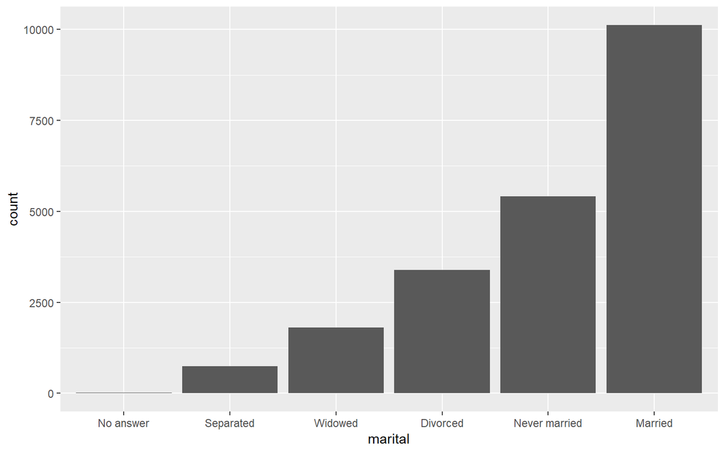

```r
gss_cat %>%
  mutate(marital = marital %>% fct_infreq() %>% fct_rev()) %>%
  ggplot(aes(marital)) +
  geom_bar()
```

## 1.4 Exercises

1. There are some suspiciously high numbers in tvhours. Is the mean a good summary?

분포를 보면 확실히 평균과 중앙값의 차이가 있다.

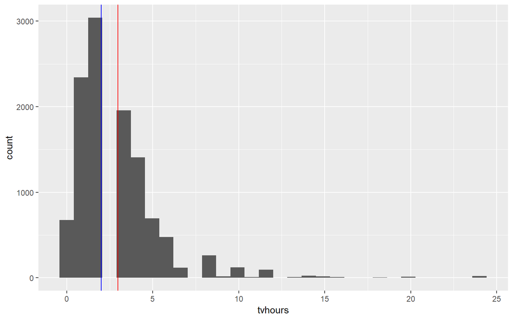

```r
gss_cat %>%
  ggplot(aes(tvhours)) +
  geom_histogram() +
  geom_vline(xintercept = mean(gss_cat$tvhours, na.rm = TRUE), colour = "red") +
  geom_vline(xintercept = median(gss_cat$tvhours, na.rm = TRUE), colour = "blue")
```

[output not shown]

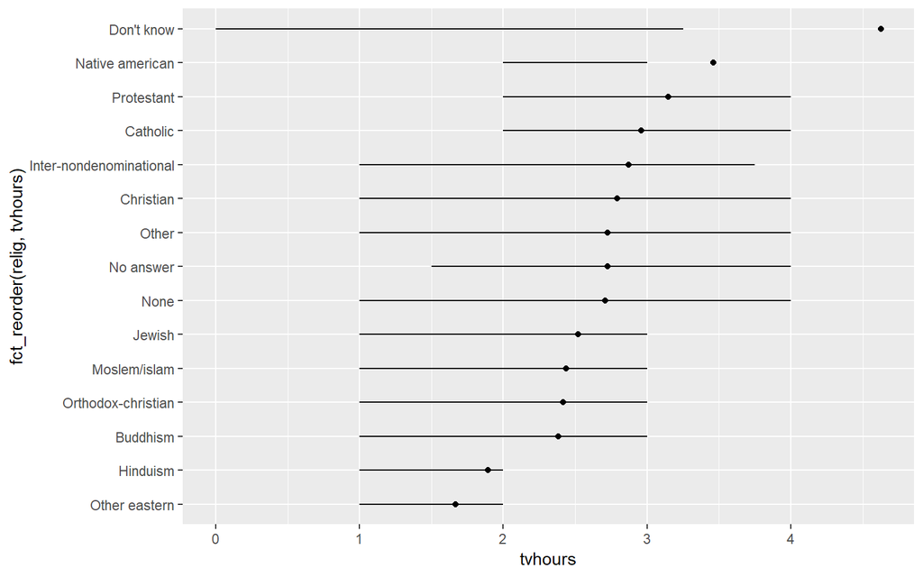

```r
gss_cat %>%
  group_by(relig) %>%
  summarize(
    age = mean(age, na.rm = TRUE),
     lq = quantile(tvhours, 0.25, na.rm = TRUE),
    uq = quantile(tvhours, 0.75, na.rm = TRUE),
    tvhours = mean(tvhours, na.rm = TRUE),
    n = n()
  ) %>%
ggplot(aes(fct_reorder(relig, tvhours), tvhours)) +
  geom_point() +
  geom_line() +
  geom_linerange(aes(ymin = lq, ymax = uq)) +
  coord_flip()
```

2. For each factor in gss_cat identify whether the order of the levels is arbitrary or principled.

```r
check_level <- function(x) if(is.factor(x)) levels(x)
lapply(gss_cat, check_level)
```

```
## $year
## NULL
##
## $marital
## [1] "No answer"     "Never married" "Separated"     "Divorced"
## [5] "Widowed"       "Married"
##
## $age
## NULL
##
## $race
## [1] "Other"          "Black"          "White"          "Not applicable"
##
## $rincome
##  [1] "No answer"      "Don't know"     "Refused"        "$25000 or more"
##  [5] "$20000 - 24999" "$15000 - 19999" "$10000 - 14999" "$8000 to 9999"
##  [9] "$7000 to 7999"  "$6000 to 6999"  "$5000 to 5999"  "$4000 to 4999"
## [13] "$3000 to 3999"  "$1000 to 2999"  "Lt $1000"       "Not applicable"
##
## $partyid
##  [1] "No answer"          "Don't know"         "Other party"
##  [4] "Strong republican"  "Not str republican" "Ind,near rep"
##  [7] "Independent"        "Ind,near dem"       "Not str democrat"
## [10] "Strong democrat"
##
## $relig
##  [1] "No answer"               "Don't know"
##  [3] "Inter-nondenominational" "Native american"
##  [5] "Christian"               "Orthodox-christian"
##  [7] "Moslem/islam"            "Other eastern"
##  [9] "Hinduism"                "Buddhism"
## [11] "Other"                   "None"
## [13] "Jewish"                  "Catholic"
## [15] "Protestant"              "Not applicable"
##
## $denom
##  [1] "No answer"            "Don't know"           "No denomination"
##  [4] "Other"                "Episcopal"            "Presbyterian-dk wh"
##  [7] "Presbyterian, merged" "Other presbyterian"   "United pres ch in us"
## [10] "Presbyterian c in us" "Lutheran-dk which"    "Evangelical luth"
## [13] "Other lutheran"       "Wi evan luth synod"   "Lutheran-mo synod"
## [16] "Luth ch in america"   "Am lutheran"          "Methodist-dk which"
## [19] "Other methodist"      "United methodist"     "Afr meth ep zion"
## [22] "Afr meth episcopal"   "Baptist-dk which"     "Other baptists"
## [25] "Southern baptist"     "Nat bapt conv usa"    "Nat bapt conv of am"
## [28] "Am bapt ch in usa"    "Am baptist asso"      "Not applicable"
##
## $tvhours
## NULL
```

3. Why did moving “Not applicable” to the front of the levels move it to the bottom of the plot?

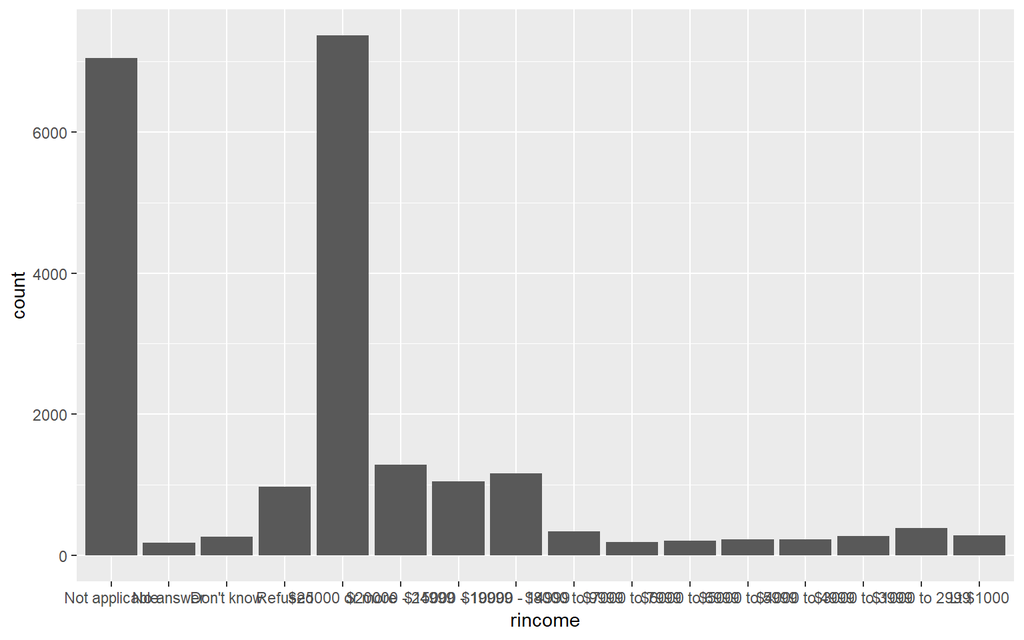

```r
gss_cat %>%
  mutate(rincome = rincome %>% fct_relevel("Not applicable")) %>%
  ggplot(aes(rincome)) +
  geom_bar()
```

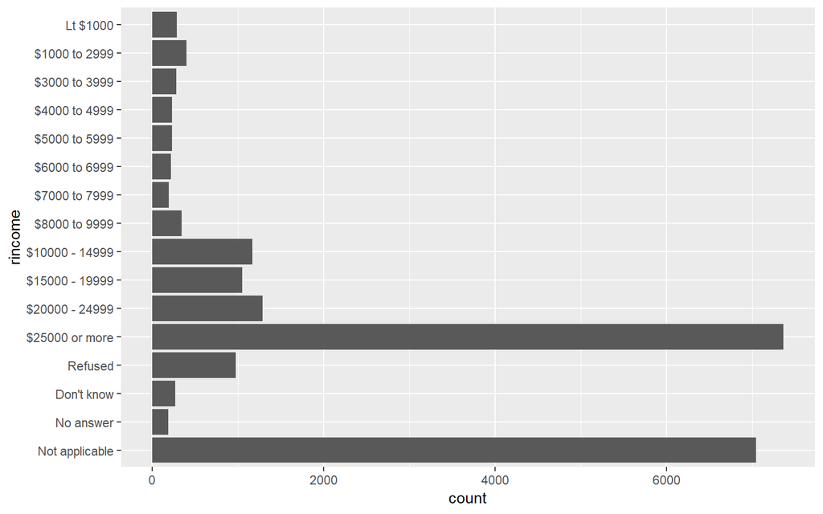

```r
gss_cat %>%
  mutate(rincome = rincome %>% fct_relevel("Not applicable")) %>%
  ggplot(aes(rincome)) +
  geom_bar() +
  coord_flip()
```

## 1.5 Modifying Factor Levels

More powerful than changing the orders of the levels is changing their values. This allows you to clarify labels for publication, and collapse levels for high-level displays `fct_recode()`

```r
gss_cat %>% count(partyid)
```

```
## # A tibble: 10 x 2
##    partyid                n
##    <fct>              <int>
##  1 No answer            154
##  2 Don't know             1
##  3 Other party          393
##  4 Strong republican   2314
##  5 Not str republican  3032
##  6 Ind,near rep        1791
##  7 Independent         4119
##  8 Ind,near dem        2499
##  9 Not str democrat    3690
## 10 Strong democrat     3490
```

레벨이 간결하고 일관적이지 않으므로 좀 더 길고 병렬구성을 사용하겠다.

```r
gss_cat %>%
  mutate(partyid = fct_recode(partyid,
    "Republican, strong" = "Strong republican",
    "Republican, weak" = "Not str republican",
    "Independent, near rep" = "Ind, near rep",
    "Independent, near dem" = "Ind, near dem",
    "Democart, weak" = "Not str democrat",
    "Democrat, strong" = "Strong democrat"
    )) %>%
  count(partyid)
```

```
## # A tibble: 10 x 2
##    partyid                n
##    <fct>              <int>
##  1 No answer            154
##  2 Don't know             1
##  3 Other party          393
##  4 Republican, strong  2314
##  5 Republican, weak    3032
##  6 Ind,near rep        1791
##  7 Independent         4119
##  8 Ind,near dem        2499
##  9 Democart, weak      3690
## 10 Democrat, strong    3490
```

그룹을 조합하기 위해, 다수의 기존 레벨을 새로운 레벨에 할당 가능

```r
gss_cat %>%
  mutate(partyid = fct_recode(partyid,
                              "Republican, strong" = "Strong republican",
                              "Republican, weak" = "Not str republican",
                              "Independent, near rep" = "Ind,near rep",
                              "Independent, near dem" = "Ind,near dem",
                              "Democrat, weak" = "Not str democrat",
                              "Democrat, strong" = "Strong democrat",
                              "Other" = "No answer",
                              "Other" = "Don't know",
                              "Other" = "Other party"
  )) %>%
  count(partyid)
```

```
## # A tibble: 8 x 2
##   partyid                   n
##   <fct>                 <int>
## 1 Other                   548
## 2 Republican, strong     2314
## 3 Republican, weak       3032
## 4 Independent, near rep  1791
## 5 Independent            4119
## 6 Independent, near dem  2499
## 7 Democrat, weak         3690
## 8 Democrat, strong       3490
```

이 기술을 사용하는것은 주의를 요한다. 실제로 다른 범주를 합치면 잘못된 결과를 야기할 수 있다.

많은 레벨을 collapse하기를 원한다면 `fct_collapse()`

```r
gss_cat %>%
  mutate(partyid = fct_collapse(partyid,
                                other = c("No answer", "Don't know", "Other party"),
                                rep = c("Strong republican", "Not str republican"),
                                ind = c("Ind,near rep", "Independent", "Ind,near dem"),
                                dem = c("Not str democrat", "Strong democrat")
  )) %>%
  count(partyid)
```

```
## # A tibble: 4 x 2
##   partyid     n
##   <fct>   <int>
## 1 other     548
## 2 rep      5346
## 3 ind      8409
## 4 dem      7180
```

때때로 단순히 작은 그룹들을 합치길 원할 있 ㅇ다.

```r
gss_cat %>%
  mutate(relig = fct_lump(relig)) %>%
  count(relig)
```

```
## # A tibble: 2 x 2
##   relig          n
##   <fct>      <int>
## 1 Protestant 10846
## 2 Other      10637
```

```r
gss_cat %>%
  mutate(relig = fct_lump(relig, n = 10)) %>%
  count(relig, sort = TRUE) %>%
  print(n = Inf)
```

```
## # A tibble: 10 x 2
##    relig                       n
##    <fct>                   <int>
##  1 Protestant              10846
##  2 Catholic                 5124
##  3 None                     3523
##  4 Christian                 689
##  5 Other                     458
##  6 Jewish                    388
##  7 Buddhism                  147
##  8 Inter-nondenominational   109
##  9 Moslem/islam              104
## 10 Orthodox-christian         95
```

## 1.6 Exercises

1. How have the proportions of people identifying as Democrat, Republican, and Independent changed over time?

`fct_reorder2()`를 사용하자

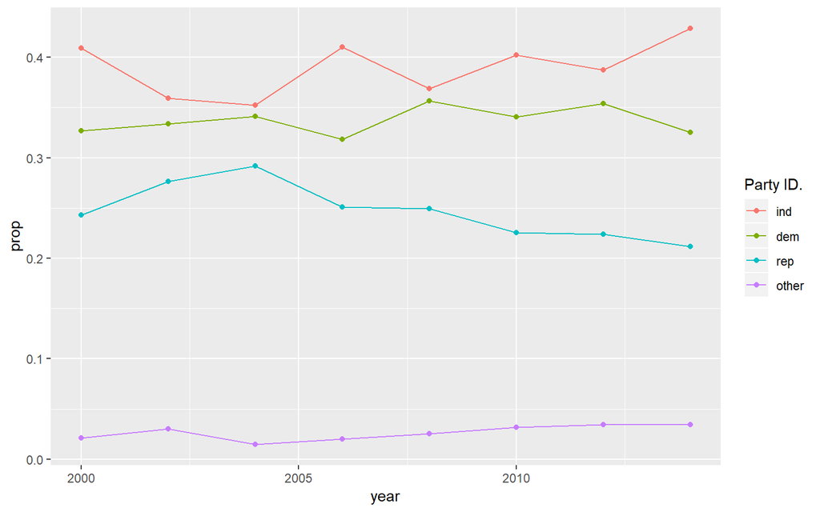

```r
gss_cat %>%
  mutate(partyid = fct_collapse(partyid,
                                other = c("No answer", "Don't know", "Other party"),
                                rep = c("Strong republican", "Not str republican"),
                                ind = c("Ind,near rep", "Independent", "Ind,near dem"),
                                dem = c("Not str democrat", "Strong democrat")
  )) %>%
  group_by(year, partyid) %>%
  summarise(n = n()) %>%
  mutate(prop = n / sum(n)) %>%
  ggplot(aes(year, prop, color = fct_reorder2(partyid, year, prop))) +
    geom_point() +
    geom_line() +
    labs(color = "Party ID.")
```

2. How could you collapse rincome into a small set of categories?

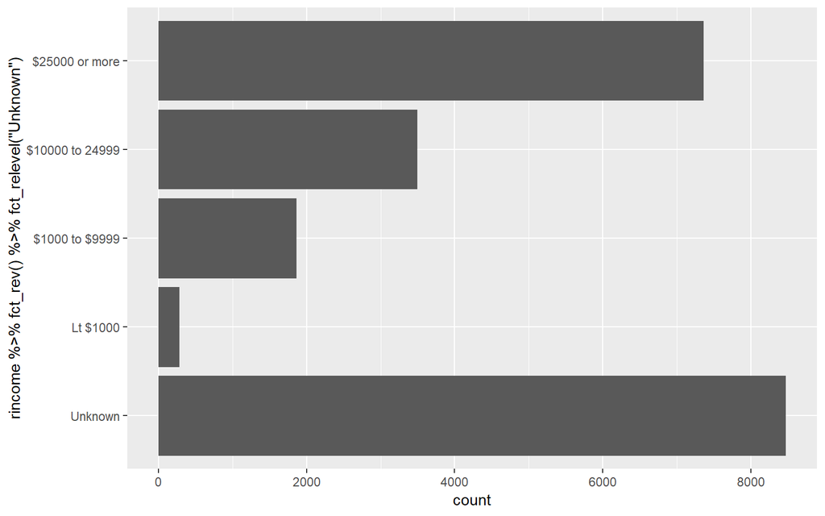

```r
gss_cat %>%
  mutate(rincome =
           fct_collapse(
             rincome,
             `Unknown` = c("No answer", "Don't know", "Refused", "Not applicable"),
            `$10000 to 24999` = str_c("$", c("20000", "15000", "10000"), " - ", c("24999", "19999", "14999")),
            `$1000 to $9999` = str_c("$", c("8000", "7000", "6000", "5000", "4000","3000","1000"), " to ", c("9999", "7999", "6999", "5999", "4999", "3999", "2999"))
           )) %>%
  ggplot(aes(rincome %>% fct_rev() %>% fct_relevel("Unknown"))) +
  geom_bar() +
  coord_flip()
```

# 2 Chapter 13 : Dates and Times with lubridate

- 매년 365일인가?
- 매일 24시간인가?
- 매분 60초인가?

```r
library(lubridate)
```

## 2.1 Creating Date/Times

```r
today()
```

```
## [1] "2018-07-29"
```

```r
now()
```

```
## [1] "2018-07-29 13:53:02 KST"
```

date/time을 만드는 세가지 방법

- 문자열
- 개별 날짜-시간 구성요소
- 기존의 날짜/시간 객체

### 2.1.1 From Strings

```r
ymd("2018-07-27")
```

```
## [1] "2018-07-27"
```

```r
mdy("January 31st, 2017")
```

[output not shown]

```r
dmy("31-Jan-2017")
```

```
## [1] "2017-01-31"
```

이러한 함수들은 인용되않은 숫자도 취한다.

```r
ymd(20170131)
```

```
## [1] "2017-01-31"
```

```r
ymd_hms("2017-01-31 20:11:59")
```

```
## [1] "2017-01-31 20:11:59 UTC"
```

```r
mdy_hm("01/31/2017 08:01")
```

```
## [1] "2017-01-31 08:01:00 UTC"
```

```r
# 시간대를 제공
ymd(20180727, tz = "UTC")
```

```
## [1] "2018-07-27 UTC"
```

### 2.1.2 From Individual Components

하나의 문자열 대신에 date-time의 개별 성분을 다수의 열에 분산시키고 싶을 수 있다.

```r
flights %>%
  select(year,month,day,hour,minute)
```

```
## # A tibble: 336,776 x 5
##     year month   day  hour minute
##    <int> <int> <int> <dbl>  <dbl>
##  1  2013     1     1     5     15
##  2  2013     1     1     5     29
##  3  2013     1     1     5     40
##  4  2013     1     1     5     45
##  5  2013     1     1     6      0
##  6  2013     1     1     5     58
##  7  2013     1     1     6      0
##  8  2013     1     1     6      0
##  9  2013     1     1     6      0
## 10  2013     1     1     6      0
## # ... with 336,766 more rows
```

```r
flights %>%
  select(year,month,day,hour,minute) %>%
  mutate(departure = make_datetime(year, month, day, hour, minute))
```

```
## # A tibble: 336,776 x 6
##     year month   day  hour minute departure
##    <int> <int> <int> <dbl>  <dbl> <dttm>
##  1  2013     1     1     5     15 2013-01-01 05:15:00
##  2  2013     1     1     5     29 2013-01-01 05:29:00
##  3  2013     1     1     5     40 2013-01-01 05:40:00
##  4  2013     1     1     5     45 2013-01-01 05:45:00
##  5  2013     1     1     6      0 2013-01-01 06:00:00
##  6  2013     1     1     5     58 2013-01-01 05:58:00
##  7  2013     1     1     6      0 2013-01-01 06:00:00
##  8  2013     1     1     6      0 2013-01-01 06:00:00
##  9  2013     1     1     6      0 2013-01-01 06:00:00
## 10  2013     1     1     6      0 2013-01-01 06:00:00
## # ... with 336,766 more rows
```

```r
make_datetime_100 <- function(year, month, day, time) {
  make_datetime(year, month, day, time %/% 100, time %% 100)
}

flights_dt <- flights %>%
  filter(!is.na(dep_time), !is.na(arr_time)) %>%
  mutate(
    dep_time = make_datetime_100(year, month, day, dep_time),
    arr_time = make_datetime_100(year, month, day, arr_time),
    sched_dep_time = make_datetime_100(
      year, month, day, sched_dep_time
    ),
    sched_arr_time = make_datetime_100(
      year, month, day, sched_arr_time
    )
  ) %>%
  select(origin, dest, ends_with("delay"), ends_with("time"))

flights_dt
```

```
## # A tibble: 328,063 x 9
##    origin dest  dep_delay arr_delay dep_time            sched_dep_time
##    <chr>  <chr>     <dbl>     <dbl> <dttm>              <dttm>
##  1 EWR    IAH           2        11 2013-01-01 05:17:00 2013-01-01 05:15:00
##  2 LGA    IAH           4        20 2013-01-01 05:33:00 2013-01-01 05:29:00
##  3 JFK    MIA           2        33 2013-01-01 05:42:00 2013-01-01 05:40:00
##  4 JFK    BQN          -1       -18 2013-01-01 05:44:00 2013-01-01 05:45:00
##  5 LGA    ATL          -6       -25 2013-01-01 05:54:00 2013-01-01 06:00:00
##  6 EWR    ORD          -4        12 2013-01-01 05:54:00 2013-01-01 05:58:00
##  7 EWR    FLL          -5        19 2013-01-01 05:55:00 2013-01-01 06:00:00
##  8 LGA    IAD          -3       -14 2013-01-01 05:57:00 2013-01-01 06:00:00
##  9 JFK    MCO          -3        -8 2013-01-01 05:57:00 2013-01-01 06:00:00
## 10 LGA    ORD          -2         8 2013-01-01 05:58:00 2013-01-01 06:00:00
## # ... with 328,053 more rows, and 3 more variables: arr_time <dttm>,
## #   sched_arr_time <dttm>, air_time <dbl>
```

출발시간에 대한 분포 시각화

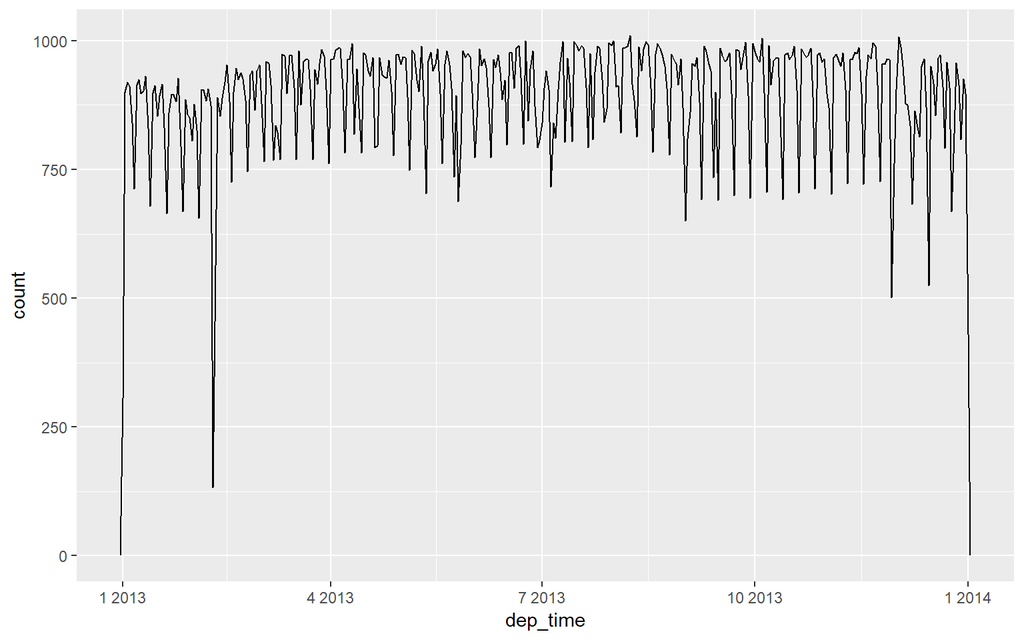

```r
flights_dt %>%
  ggplot(aes(dep_time)) +
  geom_freqpoly(binwidth = 86400) # 86400 seconds = 1 day
```

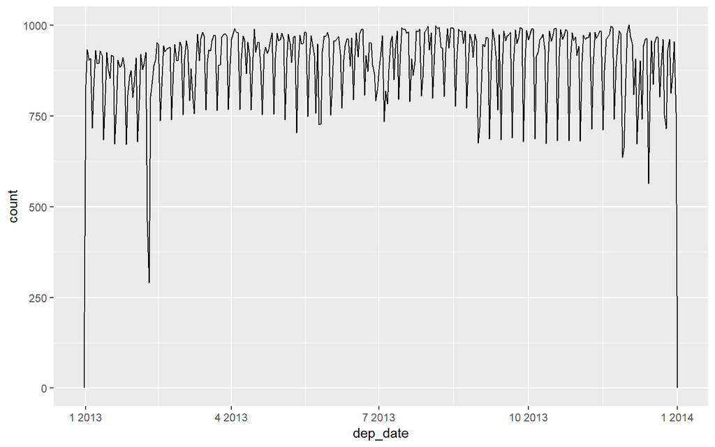

```r
# 이것과 동일하다.
flights_dt %>%
  extract(dep_time, c("dep_date", "dep_time"), "(.+) (.+)") %>%
  mutate(dep_date = as_date(dep_date)) %>%
  ggplot(aes(dep_date)) +
    geom_freqpoly(binwidth = 1) # date의 1은 하루이다.
```

하루동안의 분포

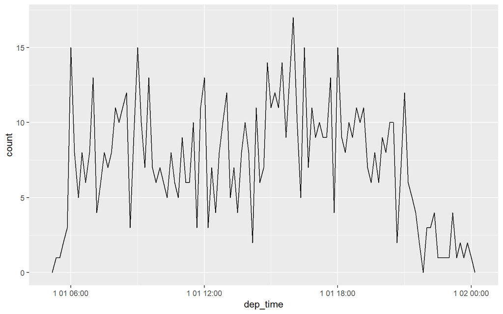

```r
flights_dt %>%
  filter(dep_time < ymd(20130102)) %>%
  ggplot(aes(dep_time)) +
    geom_freqpoly(binwidth = 600) # 600 s = 10 minutes
```

### 2.1.3 From Other Types

```r
as_datetime(today()) # date에서 datetime
```

```
## [1] "2018-07-29 UTC"
```

```r
as_date(now()) # datetime에서 date
```

```
## [1] "2018-07-29"
```

Cf. Unix time 유닉스 시간(영어: Unix time)은 시각을 나타내는 방식이다. POSIX 시간이나 Epoch 시간이라고 부르기도 한다. 1970년 1월 1일 00:00:00 협정 세계시(UTC) 부터의 경과 시간을 초로 환산하여 정수로 나타낸 것이다.[1][note 1] 유닉스 시간에서 윤초는 무시된다.[1][2][note 2] 유닉스 계열 운영 체제나 여러 다른 운영 체제, 그리고 파일 형식들에서 사용된다. 윤초 처리 방식 때문에 시간을 선형으로 표현하지 못하며, 협정 세계시의 윤초를 표현할 수 없다

UTC : Universal Time Coordinated GMT : Greenwich Mean Time

Unix Epoch

```r
as_datetime(60 * 60 * 10)
```

```
## [1] "1970-01-01 10:00:00 UTC"
```

```r
as_date(365 * 10 + 2) # 윤년 두번
```

```
## [1] "1980-01-01"
```

## 2.2 Exercises

1. What happens if you parse a string that contains invalid dates?

```r
ymd(c("2010-10-10", "bananas"))
```

```
## [1] "2010-10-10" NA
```

2. What does the tzone argument to today() do? Why is it important?

```r
today()
```

```
## [1] "2018-07-29"
```

```r
today("GMT")
```

```
## [1] "2018-07-29"
```

3. Use the appropriate lubridate function to parse each of the following dates:

```r
d1 <- "January 1, 2010"
mdy(d1)
```

[output not shown]

```r
d2 <- "2015-Mar-07"
ymd(d2)
```

```
## [1] "2015-03-07"
```

```r
d3 <- "06-Jun-2017"
dmy(d3)
```

```
## [1] "2017-06-06"
```

```r
d4 <- c("August 19, 2015", "July 1, 2015")
mdy(d4)
```

[output not shown]

```r
d5 <- "12/30/14" # Dec 30, 2014
mdy(d5)
```

```
## [1] "2014-12-30"
```

## 2.3 Date-Time Components

### 2.3.1 Getting Components

```r
datetime <- ymd_hms("2016-07-08 12:34:56")
year(datetime)
```

```
## [1] 2016
```

```r
month(datetime)
```

```
## [1] 7
```

```r
mday(datetime) # day of the month
```

```
## [1] 8
```

```r
yday(datetime) # day of the year
```

```
## [1] 190
```

```r
wday(datetime) # day of the week
```

```
## [1] 6
```

`label = TRUE` : 주의 축약된 달 또는 일 `abbr = FALSE` : 풀네임

```r
month(datetime, label = TRUE)
```

```
## [1] 7
## Levels: 1 < 2 < 3 < 4 < 5 < 6 < 7 < 8 < 9 < 10 < 11 < 12
```

```r
wday(datetime, label = TRUE, abbr = FALSE)
```

```
## [1] 금요일
## 7 Levels: 일요일 < 월요일 < 화요일 < 수요일 < 목요일 < ... < 토요일
```

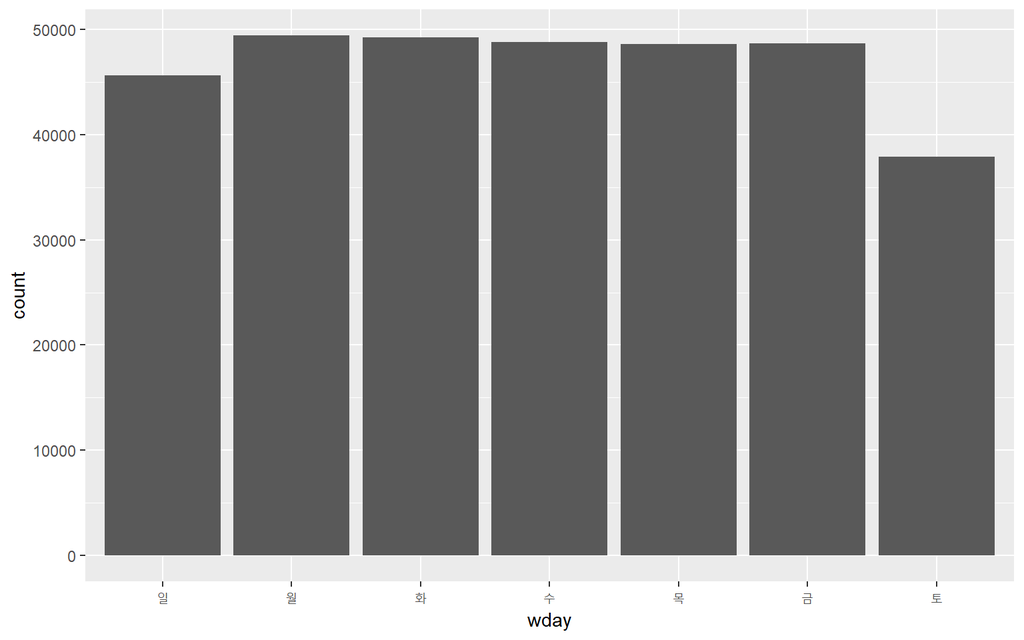

```r
flights_dt %>%
  mutate(wday = wday(dep_time, label = TRUE)) %>%
  ggplot(aes(wday)) +
    geom_bar()
```

시간내에 분에 의해 평균 출발 지연을 보면 흥미로운 패턴을 볼 수 있다. 20~30분과 50~60분이 나머지 시간보다 지연시간이 작다.

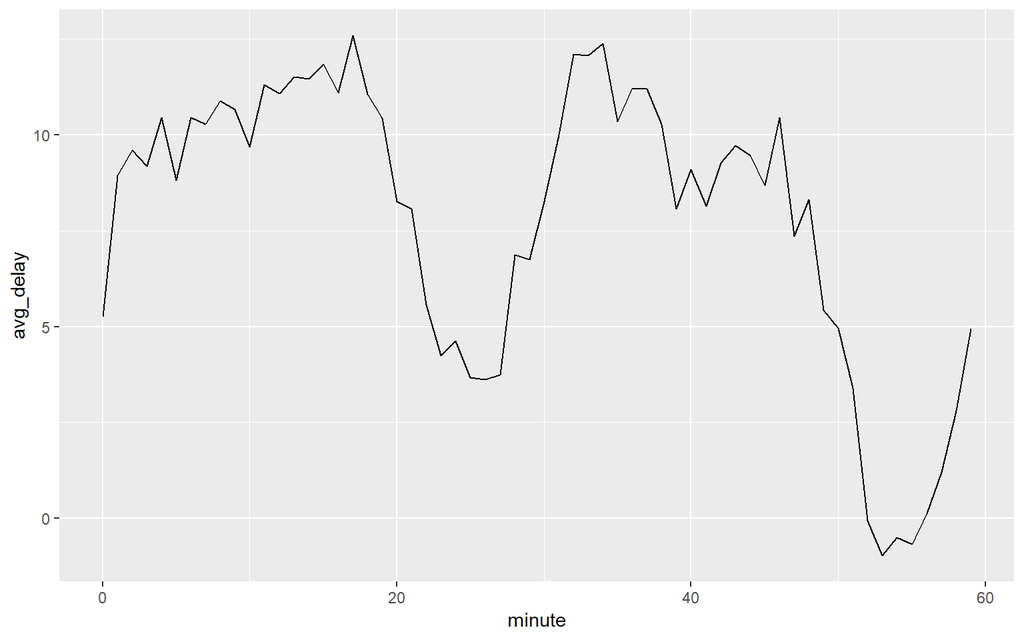

```r
flights_dt %>%
  mutate(minute = minute(dep_time)) %>%
  group_by(minute) %>%
  summarise(
    avg_delay = mean(arr_delay, na.rm = TRUE),
    n = n()) %>%
  ggplot(aes(minute, avg_delay)) +
    geom_line()
```

scheduled departure time을 보면 저런 강한패턴을 볼 수는 없다.

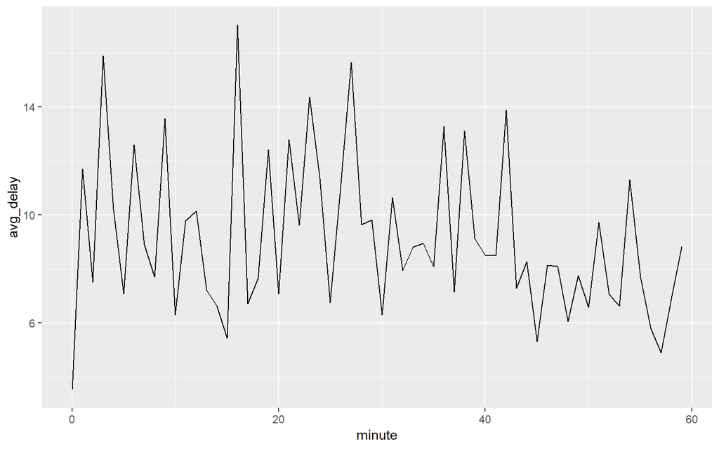

```r
sched_dep <- flights_dt %>%
  mutate(minute = minute(sched_dep_time)) %>%
  group_by(minute) %>%
  summarise(
    avg_delay = mean(arr_delay, na.rm = TRUE),
    n = n())
ggplot(sched_dep, aes(minute, avg_delay)) +
  geom_line()
```

왜 패턴을 실제 출발 시간에서 볼 수 있는가? 사람으로 부터 모아진 많은 데이터처럼 “nice”한 출발 시간인 비행으로 강한 편향이 생긴다. 사람의 판단을 포함하는 데이터로 작업할 때는 패턴의 정렬을 조심하라!

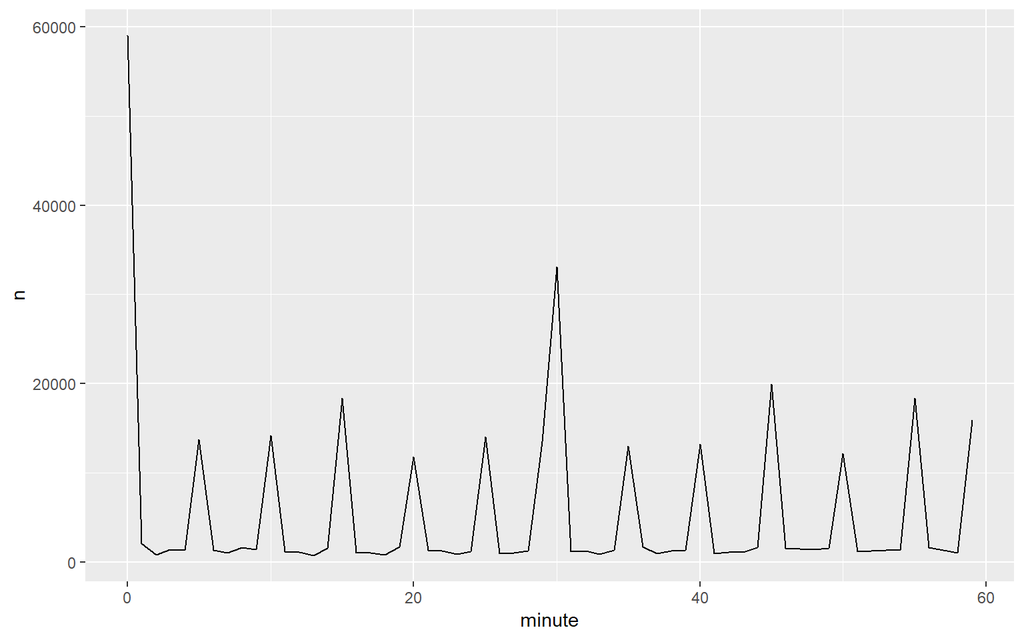

```r
ggplot(sched_dep, aes(minute, n)) +
  geom_line()
```